# Data Visualisation Part I

Francesca Mancini

1 June 2017

## Visualising your data in R

So you have been in the field and collected lots of data. What are you going to do with this treasure? Well, first of all **visualise it**! Using R to visualise your data is a good choice for different reasons:

- Anyone can recreate your visualisation (reproducibility!)
- You can do your data exploration and statistical analysis in the same environment (efficiency)
- R is incredibly flexible, you can visualise any type of data and customise your plots (flexibility and variety)
- R plots look awesome!

There is a huge variety of visualisations that you can do in R. In this lesson we will go through the most common types of plots that are used to visualise biological data. We will learn how to plot your data and how to make the plot pretty. We will use basic R functionalities. In the lesson **Data Visualisation Part II** we will learn how to make the even prettier plots using the super flexible package `ggplot2`.

## In this lesson

1. Scatterplots
2. Boxplots
3. Histograms
4. Barplots

### Scatterplots

Scatterplots are the easiest way to visualise your data. These visualisations can help you spot outliers (very extreme or unusual values) and reveal relationships between different variables. But let’s get to some code! We will be using the `iris` dataset, which gives the measurements in centimeters of the variables sepal length and width and petal length and width, respectively, for 50 flowers from each of 3 species of iris (*Iris setosa*, *versicolor*, and *virginica*).

Use the following code to read the dataset into the R environment and inspect it.

```r
data(iris)
str(iris)
```

```
## 'data.frame':    150 obs. of  5 variables:
##  $ Sepal.Length: num  5.1 4.9 4.7 4.6 5 5.4 4.6 5 4.4 4.9 ...
##  $ Sepal.Width : num  3.5 3 3.2 3.1 3.6 3.9 3.4 3.4 2.9 3.1 ...
##  $ Petal.Length: num  1.4 1.4 1.3 1.5 1.4 1.7 1.4 1.5 1.4 1.5 ...
##  $ Petal.Width : num  0.2 0.2 0.2 0.2 0.2 0.4 0.3 0.2 0.2 0.1 ...
##  $ Species     : Factor w/ 3 levels "setosa","versicolor",..: 1 1 1 1 1 1 1 1 1 1 ...
```

Let’s have a look at the variable `Sepal.Length`. The following code produces the scatterplot, assigns the title *Seapl Length (cm)* to the y axis and no title to the x axis.

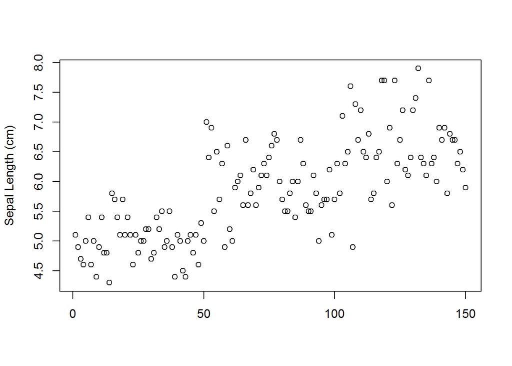

```r
plot(iris$Sepal.Length, ylab = "Sepal Length (cm)", xlab = "")
```

A more interesting plot shows the relationship between the variables `Petal.Length` and `Petal.Width`.

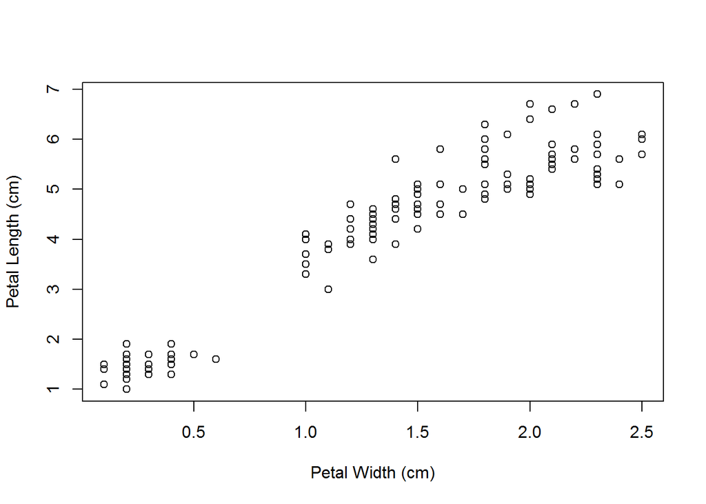

```r
plot(iris$Petal.Length ~ iris$Petal.Width, ylab = "Petal Length (cm)", xlab = "Petal Width (cm)")
```

This scatterplot shows a positive correlation between the two variables, so that flowers with longer petals also have thicker petals. We can also plot the different species in different colors, to check whether this relationship is the same in all species. The following code repeats the previous plot, changes the symbol for the points to a filled circle and assigns a different colour to data from different species.

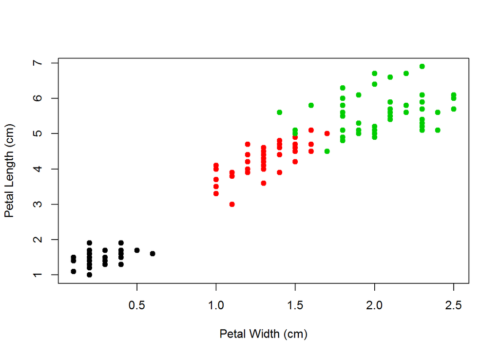

```r
plot(iris$Petal.Length ~ iris$Petal.Width,
     ylab = "Petal Length (cm)", xlab = "Petal Width (cm)",
     col = iris$Species, pch = 19)
```

From this plot we learn that the three species have different sizes of flowers and that the positive correlation between `Petal.Length` and `Petal.Width` seems to be true across species.

If we wanted to visualise the relationships between all the variables in the dataset at the same time, we could use the function `pairs`, which produces a scatterplot matrix.

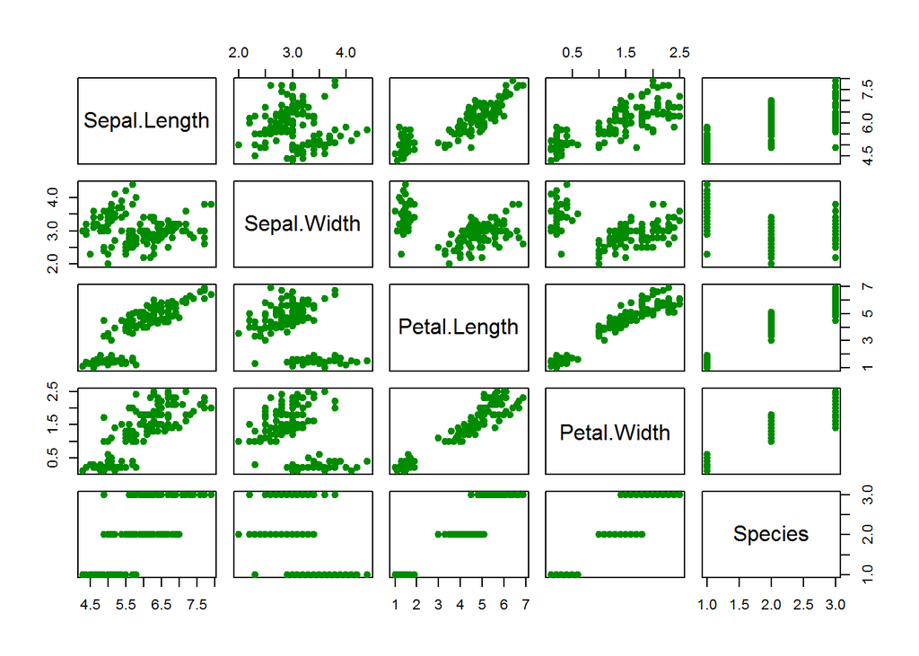

```r
pairs(iris, pch = 19, col = "Green4")
```

The last column of the matrix shows what we anticipated with the scatterplot of `Petal.Length ~ Petal.Width`, that the flowers from *Iris virginica* are bigger that those of *Iris versicolor*, which in turn are bigger that the flowers from *Iris setosa*. In the next section we will see how to improve visualisation of this type of data (categorical).

### Boxplots

Boxplots are very useful to visualise the spread of the data. They show 5 basic statistics: the minimum, the 25th percentile, the median, the 75th percentile and the maximum.

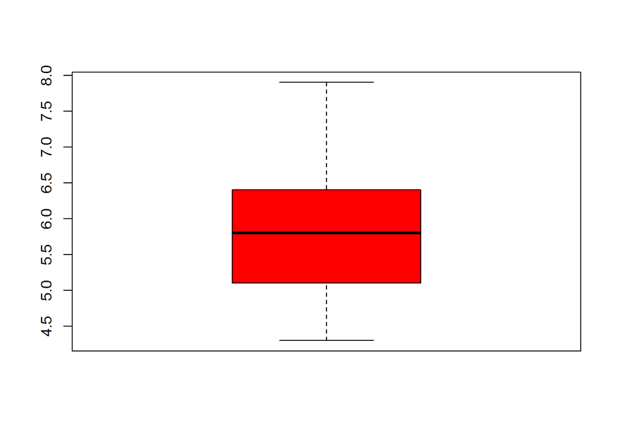

```r
boxplot(iris$Sepal.Length, col = "Red")
```

From this plot we can see that sepal length of the iris flowers goes from a minimum of roughly 4.4 cm to a maximum of roughly 8 cm, that the median value is around 5.8 cm and that the majority of values are between 5 and 6.5 cm.

We can use boxplots to compare the spread and median values of a variable across different categories. Here we will visualise the spread of `Petal.Length` in flowers from the different species.

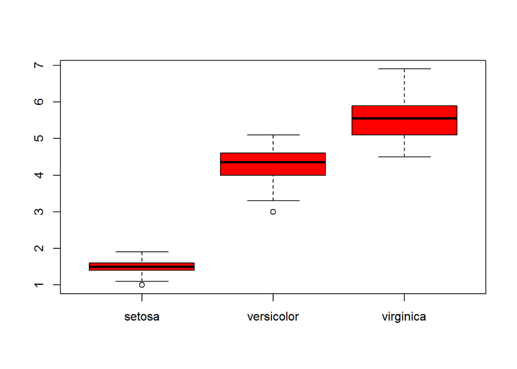

```r
boxplot(iris$Petal.Length ~ iris$Species, col = "Red")
```

Very obviously the flowers from *Iris virginica* have the longest petals. The dots bolow the bottom line of *versicolor* and *setosa* are outliers.

We can also visualise more than one plot in the same panel.

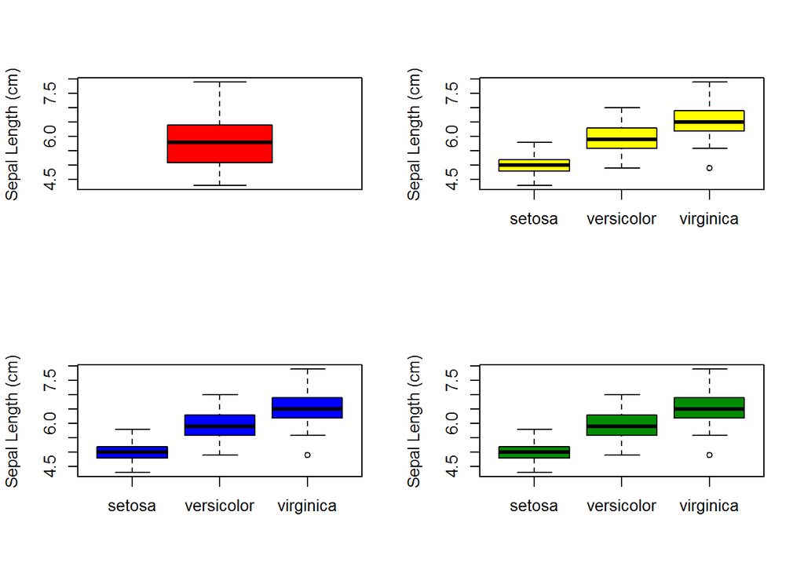

```r
par(mfrow = c(2, 2))
boxplot(iris$Sepal.Length, col = "Red", ylab = "Sepal Length (cm)")
boxplot(iris$Sepal.Length ~ iris$Species, col = "Yellow", ylab = "Sepal Length (cm)")
boxplot(iris$Sepal.Length ~ iris$Species, col = "Blue", ylab = "Sepal Length (cm)")
boxplot(iris$Sepal.Length ~ iris$Species, col = "Green4", ylab = "Sepal Length (cm)")
```

The command `par(mfrow = c(2,2))` splits the graphic window in 2 columns and 2 rows and the following lines plot one graph in each portion of the graphic window.